# Party/Date hub project

### Dimensionality reductions

```r
meanSCC_treshold <- 0.55
classification <- rep('Party', length(metrics_hq$meanSCC))
classification[metrics_hq$meanSCC <= meanSCC_treshold] <- 'Date'
#assigning the classification of party/date hub to the stats dataframe containing all infos for hubs.
stats_hq[seq(1,length(hubs_hq)), 'classification'] <- classification
```

We can plot the counts of party and date hubs using obtained using the treshold he distribution of meanSCC with the selected treshold

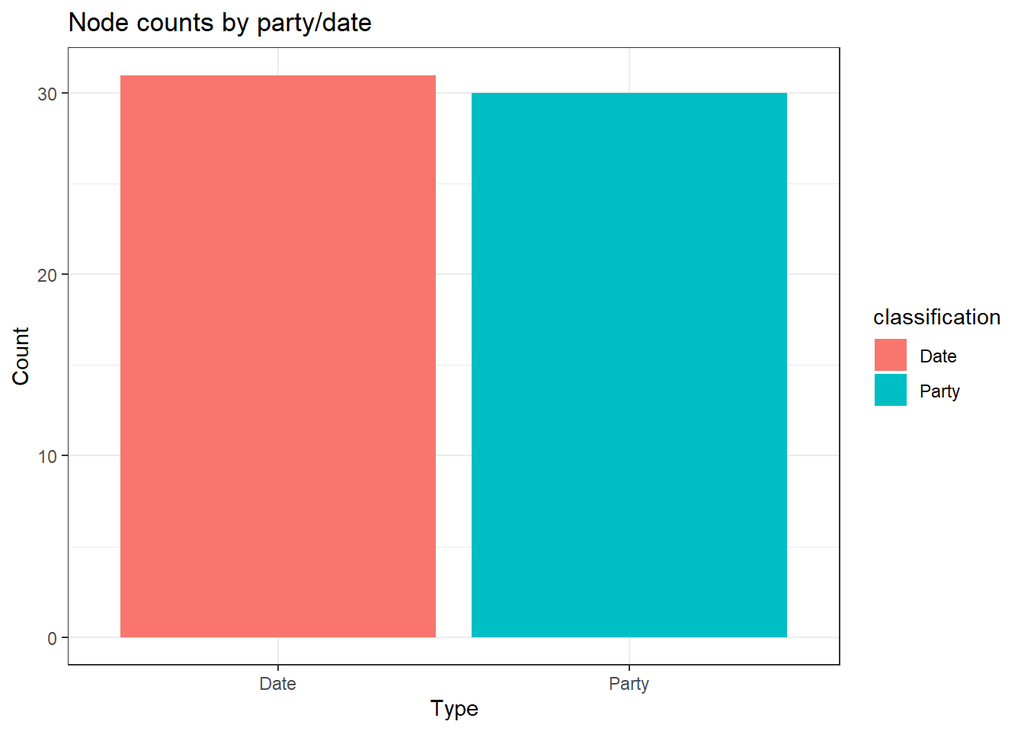

```r
ggplot(stats_hq[!is.na(stats_hq$classification),]) +
  geom_histogram(aes(x=classification, fill=classification), stat = "count") +
  ggtitle("Node counts by party/date") +
  ylab("Count") +
  xlab("Type") +
  theme_bw()
```

There is a very similar number of party and date hubs. Now we can use PCA dimensionality reduction to check if hubs clusterize according to their type. To display the PCA plot i need the transposed matrix containing the distribution of normalized counts for each node/protein representing how many interaction falls within each bin of correlation.

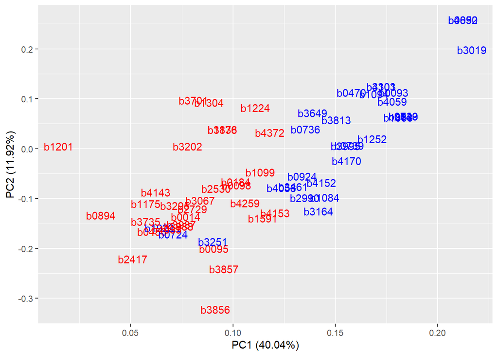

```r
normalized_counts <- function(corr_vector) {
  hist <- hist(corr_vector, breaks=intervals, plot = F)
  count <- hist$counts/sum(hist$counts)
  names(count) <- hist$mids
  return(count)
}

hubs_counts_hq <- sapply(spearmans_vector_hq, normalized_counts)
color <- ifelse((classification == 'Date'), "red", "blue")
pca_plot <- prcomp(t(hubs_counts_hq), scale = F, center = F)
autoplot(pca_plot, colour = color, label =TRUE , shape = F)
```

Hubs clusterize quite well along the first principal components (even though it explains only 40,04% of the total variance) according to the date(red) or party(blue) membership

Another dimensionality reduction technique can be applied to better infer and eventually confirm the presence of patterns in data. Umap visualization is based on the correct number of PCA principal components able to explain all the variance in data. In order to properly select the number of Principal components, we can use the so-called elbow plot.

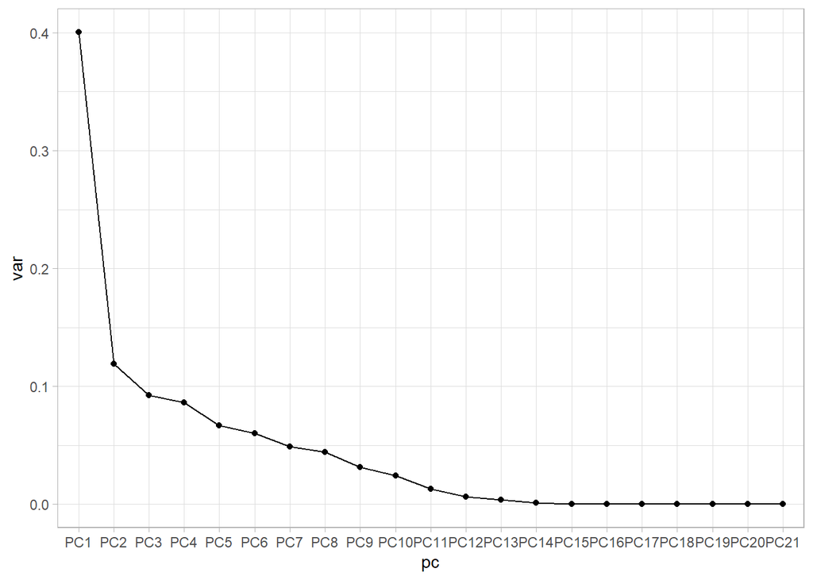

```r
pcs <- paste0("PC", seq(1,dim(pca_plot$rotation)[2]), sep = "")
pcs <- factor(pcs, level = pcs)
var = summary(pca_plot)$importance[2,]
variances <- as.data.frame(list(pc = pcs,
                                var = var))
ggplot(variances, aes(x = pc, y = var, group = 1)) +
  geom_line() +
  geom_point() +
  theme_light()
```

We can see that the variance is spread across several components. For Umap visualization it is preferable using a number of PCs well beyond the elbow. We choose 15 PCs.

```r
U<-umap(t(hubs_counts_hq), pca=15, n_components = 3)
plot3d(x=U[,1],y=U[,2],z=U[,3], col=color)
rglwidget()
```

[interactive chart not shown]

From the umap we can appreciate an even clearer division between date and party hubs.

Given all these considerations, we can now create party and date hubs categories, using and try to biologically validate them.

```r
party_hubs_hq <- as.list(filter(metrics_hq, metrics_hq$meanSCC > meanSCC_treshold))[1]
date_hubs_hq<- as.list(filter(metrics_hq, metrics_hq$meanSCC <= meanSCC_treshold))[1]
```

## Mid-Confidence Protein-Protein Interactions Analysis

The same procedures followed in the High-Confidence part of the analysis will now be applied using a treshold over `minExp` parameter above 250.

```r
#change min_exp and plot
minExp <- 250
ECOEXP_mq <-as.data.frame(cbind(Ecoli_PPI$protein1[Ecoli_PPI$experiments>minExp],
                            Ecoli_PPI$protein2[Ecoli_PPI$experiments>minExp],
                            Ecoli_PPI$experiments[Ecoli_PPI$experiments>minExp]))
colnames(ECOEXP_mq)<-c("Protein1","Protein2","Confidence")
ECOEXP_mq$Confidence<-as.numeric(ECOEXP_mq$Confidence)
```

```
## IGRAPH ecbaedd DN-- 738 2232 --
## + attr: name (v/c)
## + edges from ecbaedd (vertex names):
##  [1] b0004->b1581 b0008->b0071 b0008->b0134 b0008->b0688 b0008->b3781
##  [6] b0009->b1224 b0009->b2231 b0009->b3856 b0014->b0015 b0014->b0894
## [11] b0014->b1000 b0014->b1084 b0014->b2231 b0014->b2614 b0014->b3164
## [16] b0014->b3461 b0014->b4143 b0015->b0014 b0015->b0607 b0015->b0661
## [21] b0015->b1224 b0015->b1860 b0015->b2096 b0015->b2699 b0015->b3251
## [26] b0015->b3418 b0015->b3560 b0015->b3644 b0023->b0693 b0023->b2938
## [31] b0023->b3303 b0025->b1094 b0025->b2819 b0026->b3751 b0028->b4179
## [36] b0029->b1204 b0031->b1190 b0032->b0033 b0033->b0032 b0054->b0641
## + ... omitted several edges
```

### Node categories

```r
###define centrality measures for betweenness and degree

eco_ppi_mq_betwennes <-betweenness(eco_ppi_graph_mq,directed=FALSE)

eco_ppi_mq_degree<- degree(eco_ppi_graph_mq)

### defining threshold
treshold <- 0.9

betwenness_treshold <-quantile(eco_ppi_mq_betwennes,treshold)
betwenness_treshold <- round(betwenness_treshold, digits = 2)

degree_treshold <-quantile(eco_ppi_mq_degree,treshold)

#categorize nodes

BH<-V(eco_ppi_graph_mq)$name[eco_ppi_mq_betwennes>=betwenness_treshold & eco_ppi_mq_degree>=degree_treshold]

#non-bottleneck hubs (NBH)
NBH<-V(eco_ppi_graph_mq)$name[eco_ppi_mq_betwennes<betwenness_treshold & eco_ppi_mq_degree>=degree_treshold]

#bottleneck non-hub (BNH)
BNH<-V(eco_ppi_graph_mq)$name[eco_ppi_mq_betwennes>=betwenness_treshold & eco_ppi_mq_degree<degree_treshold]

#non bottleneck non hubs NBNH
NBNH<-V(eco_ppi_graph_mq)$name[eco_ppi_mq_betwennes<betwenness_treshold & eco_ppi_mq_degree<degree_treshold]
```

The distribution of each centrality measure can be computted.

```r
nodes_names <- c(BH, NBH, BNH, NBNH)
stats_mq <- data.frame(row.names = nodes_names,
                    list(type = c(rep('BH', length(BH)),
                                  rep('NBH', length(NBH)),
                                  rep('BNH', length(BNH)),
                                  rep('NBNH', length(NBNH))),
                    betwenness = eco_ppi_mq_betwennes[nodes_names],
                    degree = eco_ppi_mq_degree[nodes_names]))

centralities_mq <- cbind(stats_mq$degree, stats_mq$betwenness)
```

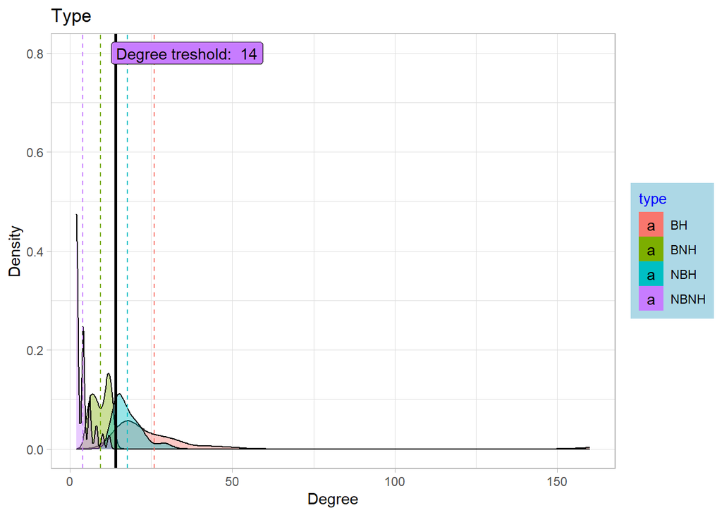

```r
#calculate the mean for each group and for each stat
mean_deg <- ddply(stats_mq, 'type', summarise, grp.mean_deg = mean(degree))
mean_bet <- ddply(stats_mq, 'type', summarise, grp.mean_bet = mean(betwenness))

degree_distr <- ggplot(stats_mq, aes(x=degree, fill=type)) +
  geom_density(alpha = 0.4)+
  geom_vline(data=mean_deg, aes(xintercept=grp.mean_deg, color=type),
             linetype="dashed") +
  geom_vline(xintercept = degree_treshold, size = 1 ) +
  geom_label(aes(x=degree_treshold +22, y = 0.8, label =paste('Degree treshold: ', degree_treshold))) +
  xlab('Degree') +
  ylab('Density') + labs(title = 'Type') +
  theme_light() +
  theme(legend.title = element_text(color = 'blue', size  = 10), legend.background = element_rect((fill = 'lightblue'), color = NA), )


betwennes_distr <- ggplot(stats_mq, aes(x=betwenness, color=type)) +
  geom_freqpoly() +
  geom_vline(xintercept = betwenness_treshold, size = 1) +
  geom_label(aes(x=betwenness_treshold + 17000, y=350, label=paste('Betweennes treshold: ', betwenness_treshold))) +
  xlab('Betwenennes') +
  ylab('Density') +
  theme_light() +
  theme(legend.title = element_text(color = 'blue', size  = 10), legend.background = element_rect((fill = 'lightblue'), color = NA), )


degree_distr
```

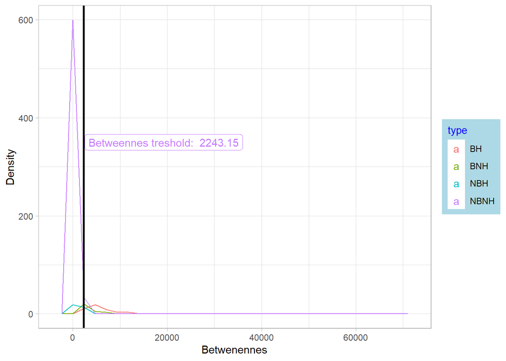

```r
betwennes_distr
```

Hub and non hubs are divided by the treshold for degree, whereas the treshold for betweenness split nodes according to bottleneckness property, as expected. Thus, all in all, the results are similar to High-confidence PPI analysis ones, with a difference in tresholds that are clearly higher. Worth mentioning is the particular shape of NBNH. We can take a better look with a violin plot:

[output not shown]

[output cut: 372 more lines]

[output not shown]

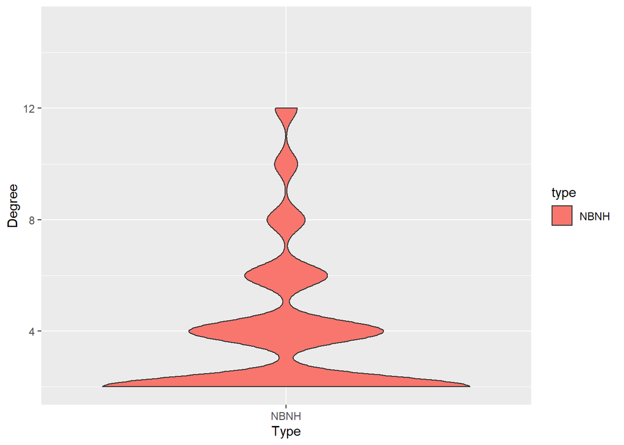

This shape shows that all degree are even in NBNH category. This is because degree function counts each edge twice (in- and out- degree).

### Compute neighborhood for each type

```r
#computing neighbors and retrieving neighbor genes for BH
BH_neighbors <- neighborhood(eco_ppi_graph_mq,1, BH)
NBH_neighbors <- neighborhood(eco_ppi_graph_mq, 1, NBH)
BNH_neighbors <- neighborhood(eco_ppi_graph_mq, 1, BNH)
NBNH_neighbors <- neighborhood(eco_ppi_graph_mq, 1, NBNH)

#remove hubs from BH neighbors
for (i in 1:length(BH_neighbors)) {
  BH_neighbors[[i]] <- BH_neighbors[[i]][BH_neighbors[[i]]$name != BH[i]]
}

#remove hubs from NBH neighbors
for (i in 1:length(NBH_neighbors)) {
  NBH_neighbors[[i]] <- NBH_neighbors[[i]][NBH_neighbors[[i]]$name != NBH[i]]
}

#remove hubs from BNH neighbors
for (i in 1:length(BNH_neighbors)) {
  BNH_neighbors[[i]] <- BNH_neighbors[[i]][BNH_neighbors[[i]]$name != BNH[i]]
}

#remove hubs from NBNH neighbors
for (i in 1:length(NBNH_neighbors)) {
  NBNH_neighbors[[i]] <- NBNH_neighbors[[i]][NBNH_neighbors[[i]]$name != NBNH[i]]
}
```

#### Correlation in gene expression for BH

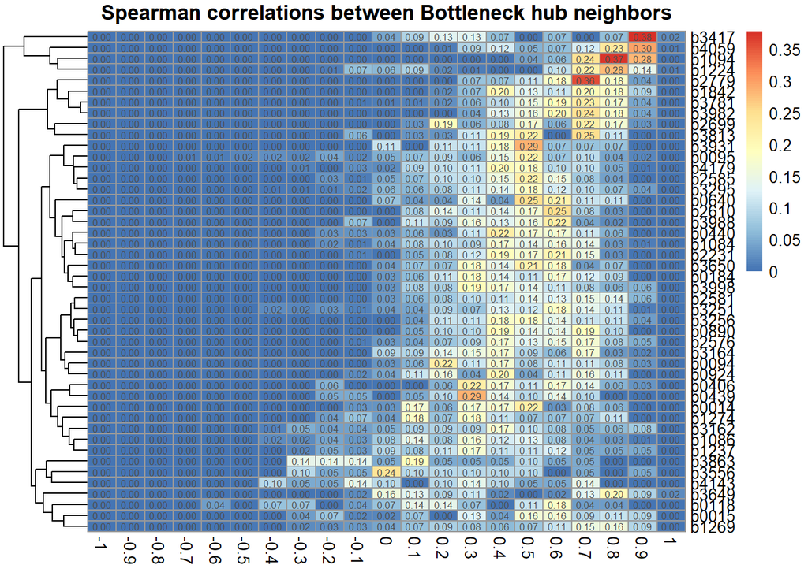

Also in this case it appears that date hubs patterns are in the lower part of the heatmap, as it can be seen from the dendrogram on the left. Results are overall more dense and noisy, due to the contribution of lower-confidence PPI.

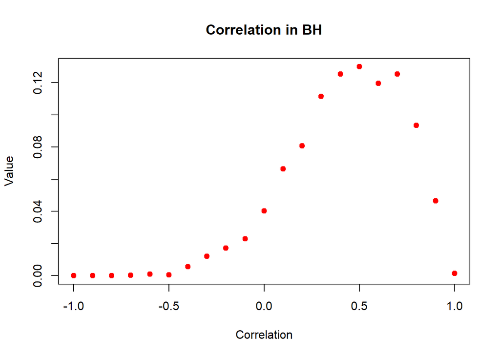

The plot showing the amount of interactions falling within each bin of correlation shows a peak around 0.5, with greater low-correlation interaction w.r.t high quality PPI analysis.

#### Correlation in gene expression for NBH

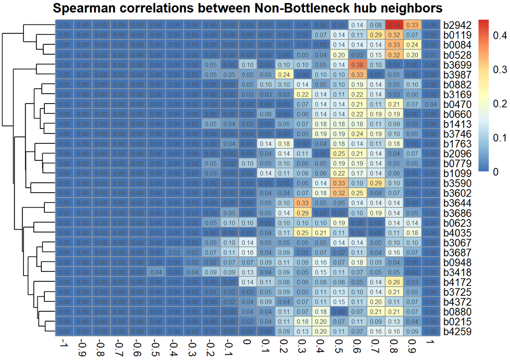

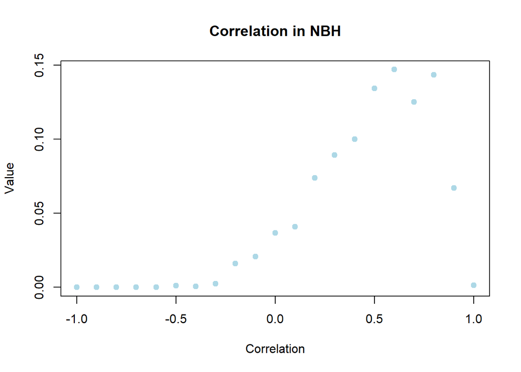

By comparing BH with NBH by looking at pattern in correlations, we can now see results more coherent with NBH and BH natures. Indeed, in NBH the peak is slightly more shifted to the right, displaying more high correlation levels interactions, in concordance with party hubs patterns.

#### Correlation in gene expression for BNH and NBNH

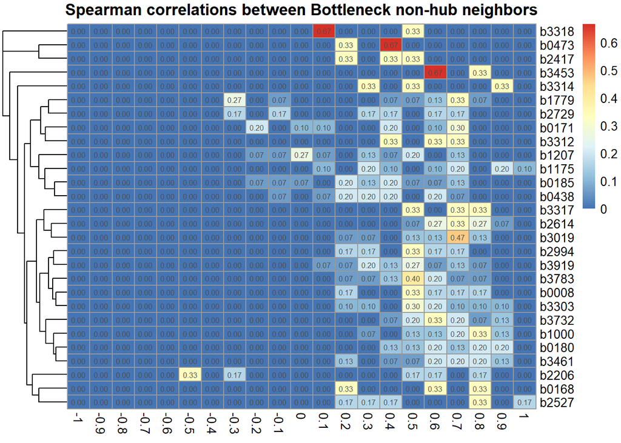

#### Correlation in gene expression for NBNH

```r
#NBNH contains neighborhood with only one interactor. These can be removed
mask <- array()
for (i in 1:length(NBNH_neighbors)) {
  mask[i] <- length(NBNH_neighbors[[i]]) != 1
}
NBNH_neighbors <- NBNH_neighbors[mask]
```

[figure not shown]

BNH and NBNH display some patterns for this part of the analysis, especially NBNH in which are depicted two main areas that differentiate between a less and a more spread distribution. However, we cannot cut the dendrogram in order to have two main clusters (corresponding to the areas) since the upper part appears to be noisy and with several anti-correlation interactions.

#### Correlation for identification

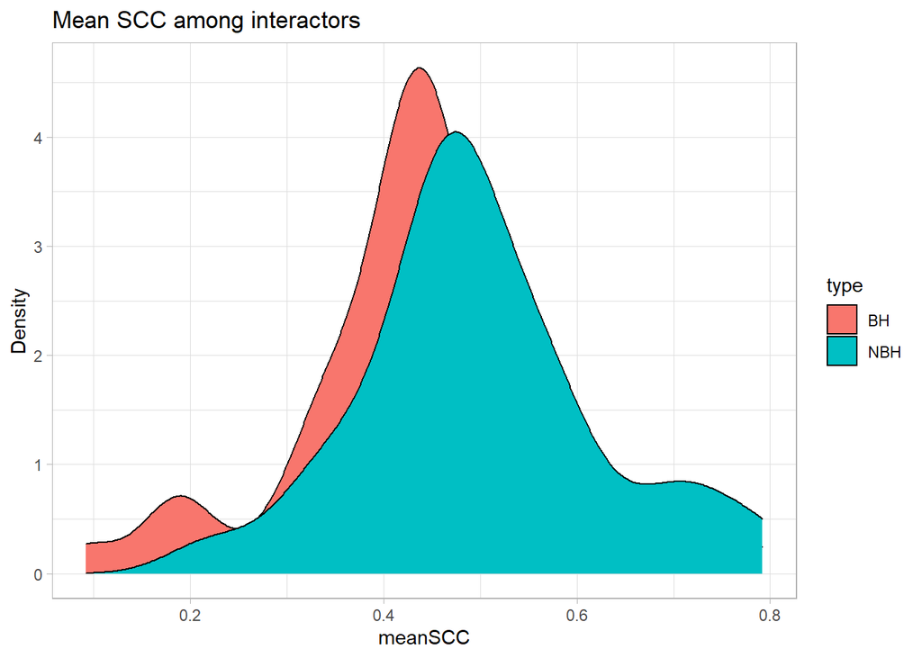

We can directly appreciate the loss of bimodality (not considering the left peak for BH, probably given by noisy interactions). However, the meanSCC for NBH now is slightly higher than BH and this is an expected outcome given NBH and BH definitions.

Variance:

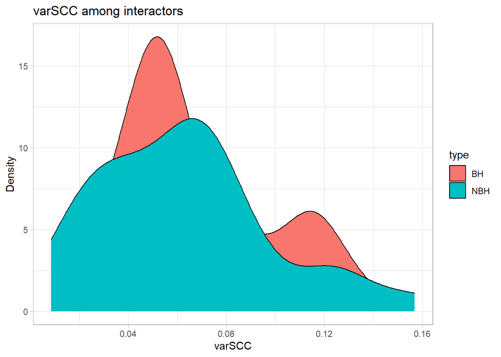

```r
ggplot(metrics_mq) +
  geom_density(aes(x=varSCC, fill=type)) +
  ggtitle("varSCC among interactors") +
  ylab("Density") +
  xlab("varSCC") +
  theme_light()
```

Here the difference with high-confidence PPI is remarkable, but expected. The inclusion of lower confidence interactions lead to a more spread variance around the mean value for both BH and NBH, where the former shows two peak (the first around 0.05 and the second 0.12).

To confirm the presence of bimodality in hubs, we can plot the distribution of the overall mean value for SCC.

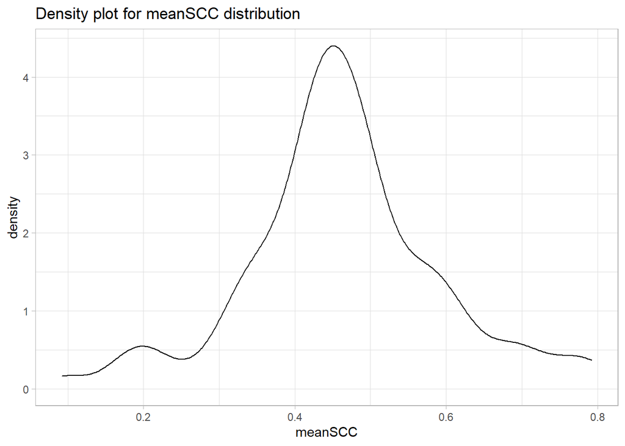

```r
ggplot(metrics_mq) +
  geom_density(aes(x=meanSCC)) +
  xlab("meanSCC") +
  ggtitle("Density plot for meanSCC distribution") +
  theme_light()
```

The bimodality necessary for the classification is totally lost. Given the design of this analysis, it’s then hard to select a treshold for properly distinguish party hubs from date hubs and, as a consequence, to continue the rest of the analysis.

## Low-Confidence Protein-Protein Interactions Analysis

The same procedures followed in the High/Mid-Confidence part of the analysis will now be applied using all the PPI interaction.

```r
#change min_exp and plot
minExp <- 0
ECOEXP_lq <-as.data.frame(cbind(Ecoli_PPI$protein1[Ecoli_PPI$experiments>minExp],
                            Ecoli_PPI$protein2[Ecoli_PPI$experiments>minExp],
                            Ecoli_PPI$experiments[Ecoli_PPI$experiments>minExp]))
colnames(ECOEXP_lq)<-c("Protein1","Protein2","Confidence")
ECOEXP_lq$Confidence<-as.numeric(ECOEXP_lq$Confidence)
```

```
## IGRAPH 0ce02e2 DN-- 1240 6060 --
## + attr: name (v/c)
## + edges from 0ce02e2 (vertex names):
##  [1] b0002->b3931 b0002->b4052 b0004->b1581 b0004->b1896 b0008->b0071
##  [6] b0008->b0134 b0008->b0688 b0008->b3781 b0009->b1224 b0009->b2231
## [11] b0009->b3856 b0014->b0015 b0014->b0438 b0014->b0661 b0014->b0894
## [16] b0014->b0962 b0014->b1000 b0014->b1084 b0014->b1860 b0014->b2231
## [21] b0014->b2469 b0014->b2526 b0014->b2614 b0014->b2690 b0014->b2942
## [26] b0014->b3164 b0014->b3461 b0014->b3517 b0014->b3594 b0014->b3649
## [31] b0014->b3985 b0014->b4000 b0014->b4143 b0014->b4203 b0015->b0014
## [36] b0015->b0094 b0015->b0171 b0015->b0607 b0015->b0661 b0015->b0882
## + ... omitted several edges
```

### Node categories

```r
###define centrality measures for betweenness and degree

eco_ppi_lq_betwennes <-betweenness(eco_ppi_graph_lq,directed=FALSE)

eco_ppi_lq_degree<- degree(eco_ppi_graph_lq)

### defining threshold
treshold <- 0.9

betwenness_treshold <-quantile(eco_ppi_lq_betwennes,treshold)
betwenness_treshold <- round(betwenness_treshold, digits = 2)

degree_treshold <-quantile(eco_ppi_lq_degree,treshold)

#categorize nodes

BH<-V(eco_ppi_graph_lq)$name[eco_ppi_lq_betwennes>=betwenness_treshold & eco_ppi_lq_degree>=degree_treshold]

#non-bottleneck hubs (NBH)
NBH<-V(eco_ppi_graph_lq)$name[eco_ppi_lq_betwennes<betwenness_treshold & eco_ppi_lq_degree>=degree_treshold]

#bottleneck non-hub (BNH)
BNH<-V(eco_ppi_graph_lq)$name[eco_ppi_lq_betwennes>=betwenness_treshold & eco_ppi_lq_degree<degree_treshold]

#non bottleneck non hubs NBNH
NBNH<-V(eco_ppi_graph_lq)$name[eco_ppi_lq_betwennes<betwenness_treshold & eco_ppi_lq_degree<degree_treshold]
```

The distribution of each centrality measure can be visualized.

```r
nodes_names_lq <- c(BH, NBH, BNH, NBNH)
stats_lq <- data.frame(row.names = nodes_names_lq,
                    list(type = c(rep('BH', length(BH)),
                                  rep('NBH', length(NBH)),
                                  rep('BNH', length(BNH)),
                                  rep('NBNH', length(NBNH))),
                    betwenness = eco_ppi_lq_betwennes[nodes_names_lq],
                    degree = eco_ppi_lq_degree[nodes_names_lq]))

centralities_lq <- cbind(stats_lq$degree, stats_lq$betwenness)
```

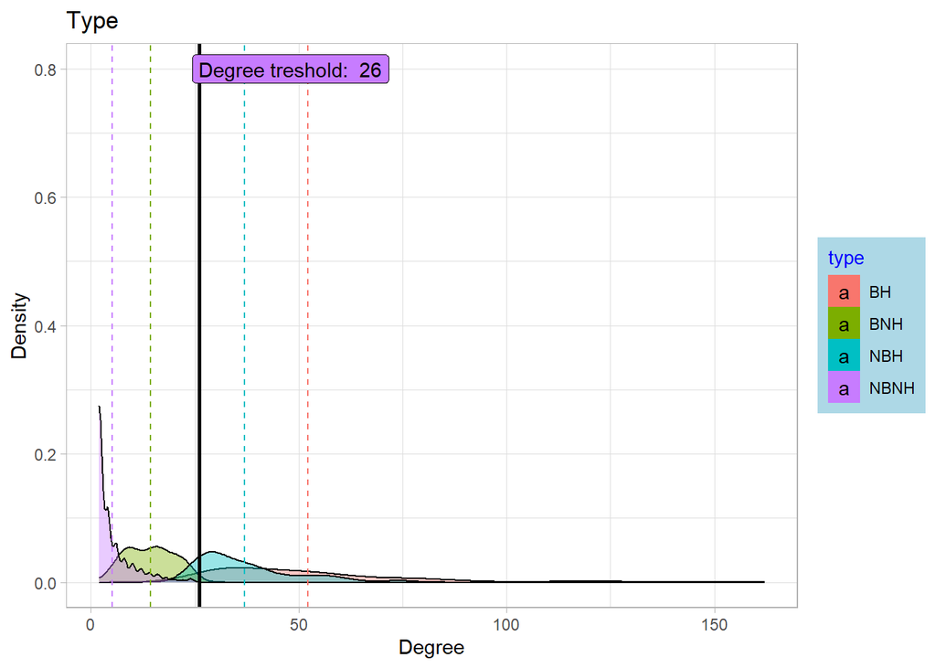

```r
#calculate the mean for each group and for each stat
mean_deg <- ddply(stats_lq, 'type', summarise, grp.mean_deg = mean(degree))
mean_bet <- ddply(stats_lq, 'type', summarise, grp.mean_bet = mean(betwenness))

degree_distr <- ggplot(stats_lq, aes(x=degree, fill=type)) +
  geom_density(alpha = 0.4)+
  geom_vline(data=mean_deg, aes(xintercept=grp.mean_deg, color=type),
             linetype="dashed") +
  geom_vline(xintercept = degree_treshold, size = 1 ) +
  geom_label(aes(x=degree_treshold +22, y = 0.8, label =paste('Degree treshold: ', degree_treshold))) +
  xlab('Degree') +
  ylab('Density') + labs(title = 'Type') +
  theme_light() +
  theme(legend.title = element_text(color = 'blue', size  = 10), legend.background = element_rect((fill = 'lightblue'), color = NA), )


betwennes_distr <- ggplot(stats_lq, aes(x=betwenness, color=type)) +
  geom_freqpoly() +
  geom_vline(xintercept = betwenness_treshold, size = 1) +
  geom_label(aes(x=betwenness_treshold + 17000, y=350, label=paste('Betweennes treshold: ', betwenness_treshold))) +
  xlab('Betwenennes') +
  ylab('Density') +
  theme_light() +
  theme(legend.title = element_text(color = 'blue', size  = 10), legend.background = element_rect((fill = 'lightblue'), color = NA), )


degree_distr
```

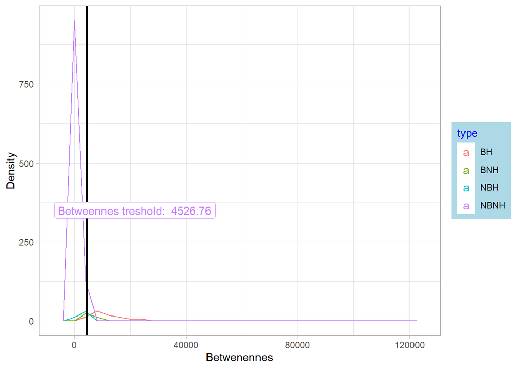

```r
betwennes_distr
```

Also in this case, tresholds (higher in values w.r.t previous analyses) divide nodes according to their properties. Degree distributions are flatter, especially for BH, and the zig-zag pattern of NBNH due to even degree is more evident:

[output not shown]

[output cut: 372 more lines]

[output not shown]

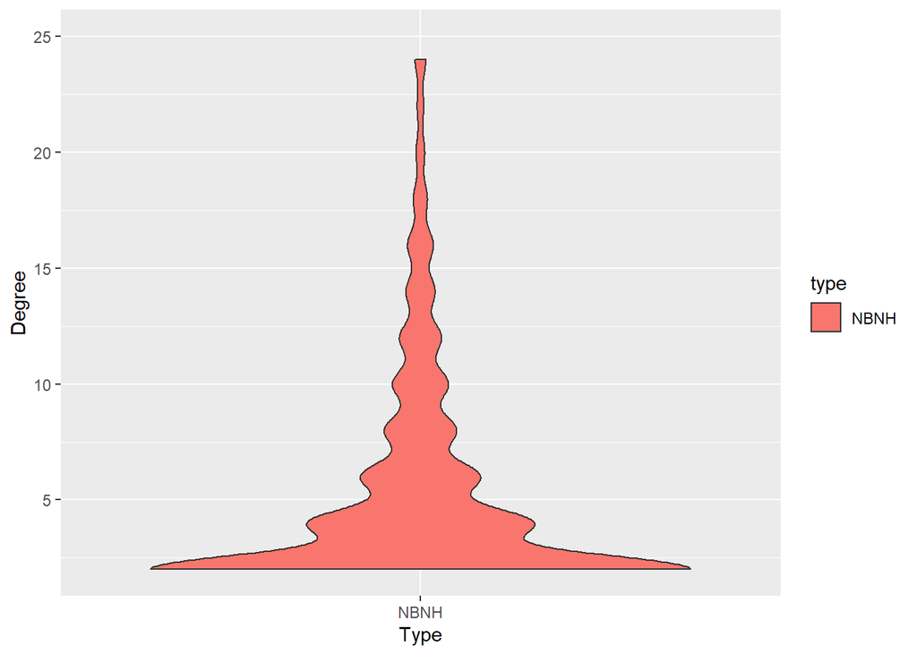